# Gain Drifts systematics

# Mitigating Gain Drifts

We aim at mitigating the leakage by regressing against a template (in this case just the CMB Dipole). We therefore split the TOD into **chunks of 10 min** and estimate the gain and correct the TOD on each chunk of observation.

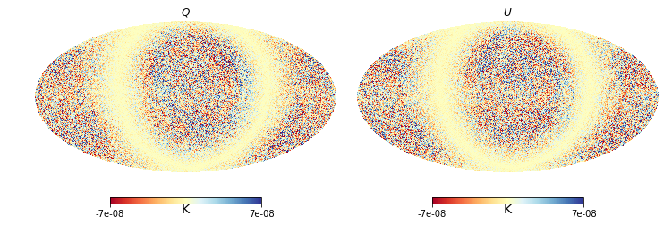

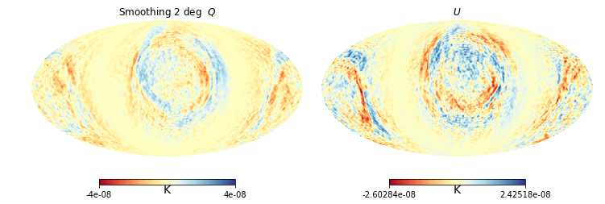

```python
driftcorrmap= hp.read_map(field=range(3) ,
                       filename='/Users/peppe/work/satellite_sims/drifting_gain/corr/madam_bmap_011.fits',
                       verbose=False)
cldriftcorrdip=hp.anafast(driftcorrmap  , lmax=lmax)
fig=pl.figure(figsize=(15,8))
hp.mollview(driftcorrmap [1] , unit='K',title=r'$  Q  $', sub=132 , fig=fig ,cmap=cmap  ,min=-7e-8, max=7e-8  )
hp.mollview(driftcorrmap [2] ,unit='K', title=r'$  U   $', sub=133 , fig=fig ,cmap=cmap   ,min=-7e-8, max=7e-8   )

driftcorrmap= hp.smoothing(map_in=driftcorrmap, fwhm=pl.deg2rad(2.) , verbose=False )
fig=pl.figure(figsize=(15,8))
hp.mollview(driftcorrmap [1] , unit='K',title= 'Smoothing 2 deg  ' + r'$  Q  $' , sub=132 , fig=fig ,cmap=cmap ,min=-4e-8, max=4e-8     )
hp.mollview(driftcorrmap [2] ,unit='K', title=r'$  U   $', sub=133 , fig=fig ,cmap=cmap   )
```

```python
import scipy as sp
from scipy import interpolate
from scipy import optimize
from scipy import integrate
from iminuit import  Minuit
import numpy as np
def get_delta_r(inputcl, lmax=200, wp = 7.6, fsky=1.,b=1.e-2, n_steps=1024):
        lmin=2

        ell=pl.arange(lmin, lmax)
        tenscl =interpolate.interp1d (ell,
                 pl.loadtxt('/Users/peppe/work/satellite_sims/Class_planck2015_r1_cl_unlensed.dat')[:,3][lmin:lmax])
        lenscl =interpolate.interp1d (ell,
                pl.loadtxt('/Users/peppe/work/satellite_sims/Class_planck2015_r0_cl_lensed.dat')[:,3][lmin:lmax ])
        nl_w=interpolate.interp1d (ell, inputcl[lmin:lmax]   )
        clobs   =lambda  r, l : lenscl(l) +  nl_w(l)
        cltheor =lambda r,l:  r *tenscl(l)+    lenscl(l)
        logP    =lambda r, r_inp,l: -   0.5*(2.*l +1 )*(clobs(r_inp,l)/cltheor(r,l)  +pl.log(cltheor(r,l)) -(2. *l -1)/(2.*l+1) *pl.log(clobs(r_inp,l)))
        func=lambda x: - pl.sum( logP(x, 0, ell)  )

        #m=Minuit(func, x=1e-3 , error_x=0.0001, limit_x=(0.,1e-2), errordef=1e-8 , print_level=0)
        m=Minuit(func, x=1e-3 , error_x=0.0001, limit_x=(0.,b), errordef=1e-8 , print_level=0)

        m.migrad()
        rmax= m.values['x']
        L       =lambda r: pl.exp ((logP(r,0,ell)   ).sum() - ( logP(rmax , 0, ell)  ).sum() )
        Lmap= map(L, pl.linspace(0,b, n_steps ) )/L(rmax)
        a=0

        integr_steps=n_steps
        Normalization= integrate.quad(L, a=a, b=b , limit=1000, epsrel=1e-8)[0]
        R=0
        dr= (b-a)/integr_steps

        deltar=a
        it_counter=0
        while R<0.6801 and deltar<b :
                deltar+=dr
                R=  integrate.quad(L, a=a , b=deltar, limit=1000, epsrel=1e-8)[0] / Normalization
                it_counter+=1

        deltar/=pl.sqrt(fsky)
        #print "Delta r= %.2f x 10^-3  found after %d iterations at %g per cent C.L.  "%(  deltar*1000,it_counter, R  )
        return Lmap, deltar, rmax

l2=pl.arange(2, 501)
Lcorr,deltar2,r2= get_delta_r(cldriftcorrdip[2]*1e12 ,lmax=200 , wp=wp, n_steps=2048 )
```

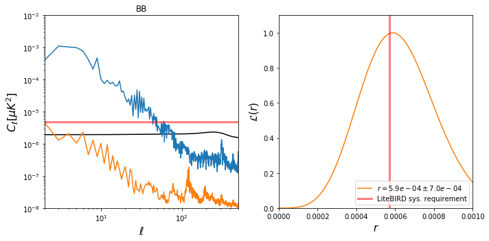

```python
fig=pl.figure(figsize=(10 , 5) )

pl.subplot(121)

pl.title('BB')
pl.loglog(l, cl[ 2:lmax+1,3]  ,'k')
pl.loglog(l, cldriftdip [2][2:]  *1e12)
pl.xlabel(r'$\ell$', fontsize=16)
pl.ylabel(r'$ C_{\ell}    [ \mu K^2 ]$', fontsize=16)
pl.loglog(l, cldriftcorrdip[2][2:]   *1e12)

pl.loglog(l, pl.ones_like(l)*Nl0,'r', alpha=.5, linewidth=3)
pl.ylim([1e-8,1e-2])
foo=pl.xlim([2,500])
pl.subplot(122)


#pl.plot(np.linspace(0,.1, 512), Lref, label=''+r'$  r= %.3f \pm %.3f    $'%(rref,deltaref ),
#        color='red' ,alpha=.5, linewidth=3)
pl.plot([1], [1e-14])
pl.plot(np.linspace(0,.01, 2048), Lcorr, label=r'$  r=%.1e\pm %.1e   $'%(r2, deltar2 ) )
pl.axvline( x=0.57e-3, color='r', alpha=.5, linewidth=3,label='LiteBIRD sys. requirement')
pl.xlim([0., .1e-2])
pl.ylim([0.,1.1 ])
pl.legend(loc='best')
pl.xlabel(r'$r$', fontsize=15)
pl.ylabel(r'$\mathcal{L}(r)$', fontsize=15)
pl.tight_layout()
```

**Caption**: (Left) solid blue B-mode power spectrum of maps encoding drift leakage, solid orange B-mode power spectrum with drift mitigation. Notice that the amplitude is reduced by twwo orders of magnitude. (right) . Posterior likelihood on $r$ of the BB spectrum with drift mitigation.

## Drifts w/o the CMB Dipole

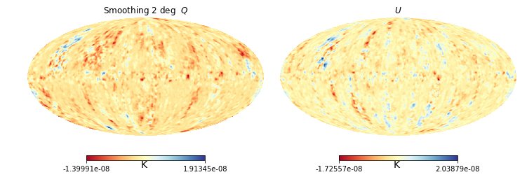

```python
driftmap= hp.read_map(field=range(3) ,
                       filename='/Users/peppe/work/satellite_sims/drifting_gain/uncorr/madam_bmap_015.fits',
                       verbose=False)
cldriftT=hp.anafast(driftmap , lmax=lmax)
driftmap= hp.smoothing(map_in=driftmap, fwhm=pl.deg2rad(2.), verbose=False)
fig=pl.figure(figsize=(15,8))

hp.mollview(driftmap [1], unit='K ', title='Smoothing 2 deg  ' +r'$  Q$', sub=132 , fig=fig,cmap=cmap )

hp.mollview(driftmap [2], unit='K ', title=r'$U$', sub=133 , fig=fig ,cmap=cmap   )
```

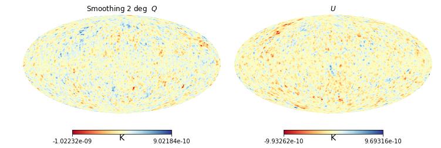

```python
driftcorrmap= hp.read_map(field=range(3) ,
                       filename='/Users/peppe/work/satellite_sims/drifting_gain/corr/madam_bmap_016.fits',
                       verbose=False)
cldriftcorrT=hp.anafast(driftcorrmap  , lmax=lmax)
driftcorrmap= hp.smoothing(map_in=driftcorrmap, fwhm=pl.deg2rad(2.), verbose=False )
fig=pl.figure(figsize=(15,8))
hp.mollview(driftcorrmap [1] , unit='K',title='Smoothing 2 deg  ' +r'$  Q  $', sub=132 , fig=fig ,cmap=cmap     )
hp.mollview(driftcorrmap [2] ,unit='K', title=r'$  U   $', sub=133 , fig=fig ,cmap=cmap   )
```

```python
Luncorr,deltar1,r1= get_delta_r(cldriftT[2]*1e12 ,lmax=200 , wp=wp, n_steps=2048 )
Lcorr,deltar2,r2= get_delta_r(cldriftcorrT[2]*1e12 ,lmax=100 , wp=wp, n_steps=2048 )
```

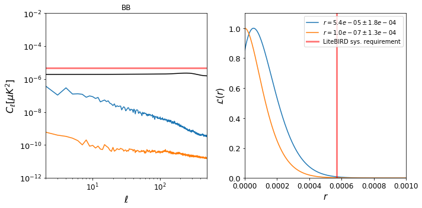

```python
fig=pl.figure(figsize=(10 , 5) )

pl.subplot(121)

pl.title('BB')
pl.loglog(l, cl[ 2:lmax+1,3]  ,'k')
pl.loglog(l, cldriftT [2][2:]  *1e12)

pl.loglog(l, cldriftcorrT[2][2:]   *1e12)

pl.loglog(l, pl.ones_like(l)*Nl0,'r', alpha=.5, linewidth=3)
pl.ylim([1e-12,1e-2])
foo=pl.xlim([2,500])
pl.yticks(fontsize=13)
pl.xticks(fontsize=12)
pl.xlabel(r'$\ell$', fontsize=16)
pl.ylabel(r'$ C_{\ell}    [ \mu K^2 ]$', fontsize=16)
pl.subplot(122)


pl.plot(np.linspace(0,1e-2, 2048), Luncorr, label=r'$  r=%.1e \pm %.1e   $'%(r1, deltar1) )
pl.plot(np.linspace(0,1e-2,2048), Lcorr, label=r'$  r=%.1e \pm %.1e    $'%(r2, deltar2 ) )
pl.axvline( x=0.57e-3, color='r', alpha=.5, linewidth=3,label='LiteBIRD sys. requirement')
pl.xlim([0., .1e-2])
pl.ylim([0.,1.1 ])
pl.legend(loc='best')
pl.yticks(fontsize=13)
pl.xticks(fontsize=12)

pl.xlabel(r'$r$', fontsize=15)
pl.ylabel(r'$\mathcal{L}(r)$', fontsize=15)
pl.tight_layout()
```